# Drawing the Borders of Olfactory Space

Emily J Mayhew, Charles J Arayata, Richard C. Gerkin, Brian K. Lee, Jonathan Magill, Lindsey L Snyder, Kelsie Little, Chung Wen Yu, Joel D Mainland

23 March, 2022

# 1 In this markdown

This markdown trains models, conducts analyses, and generates figures presented in the manuscript Transport Features Predict If a Molecule is Odorous.

(bioRxiv preprint: https://doi.org/10.1101/2020.12.04.412254)

```r
#load required packages
pacman::p_load(tidyverse, caret, xgboost, FactoMineR, DMwR, nnet, ROCR, plotly, knitr, RRF, ggmap, cowplot)
```

# 2 Process data

## 2.1 Read in data tables

```r
#read in supplemental data tables
S1 <- read.csv("tables/S1.csv", stringsAsFactors = F)
S2 <- read.csv("tables/S2.csv", stringsAsFactors = F)
S3 <- read.csv("tables/S3.csv", stringsAsFactors = F)
```

## 2.2 Partition data

```r
#make odor class a factor
S1 <- S1 %>%
  mutate(odor.class = factor(odor.class,
                              levels = c("Odorless", "Odor")))

# #split dataset based on assignment in "dataset.assigned" column
 train <- S1 %>% filter(dataset.assigned != "test")
# #validation <- S1 %>% filter(dataset.assigned == "validation") #combined with train for final model
 test <- S1 %>% filter(dataset.assigned == "test")
```

## 2.3 Pre-process and rebalance training set

```r
#select only columns needed for model training
train <- train %>% select(odor.class, boiling.point.best.available, vapor.pressure.best.available:Infective.50)

#generate pre-processing procedure to scale (0 to 1), drop variables with near zero variance, drop highly correlated variables
set.seed(111)
preProc <- preProcess(train[,-1], method = c("range", "zv", "corr"), na.remove = TRUE, verbose = FALSE, k=5, freqCut = 95/5, uniqueCut = 10, cutoff = 0.99, rangeBounds = c(0, 1))

#apply pre-processing to datasets
train_scaled <- predict(preProc, train)
test_scaled <- predict(preProc, test)
ALL_scaled <- predict(preProc, S1)

#apply SMOTE procedure to rebalance odor:odorless examples
set.seed(123)
#uses scaled data (for everything model)
train_smote <- SMOTE(odor.class ~., train_scaled, perc.over = (100 + 50*6), k=5, perc.under = 200)
```

# 3 Train models

```r
# set seeds and training parameters

#generate list of seeds to use in training models
set.seed(724)
train.seeds <- sample(1:999, 10, replace=FALSE)

#set training parameters
fit.control <- trainControl(
  method = "repeatedcv",
  number = 5,
  repeats = 2,
  savePredictions = T,
  returnResamp = "all",
  classProbs = T,
  summaryFunction = twoClassSummary)

#regularized xgb-linear tuning grid
xgbTuningGrid = expand.grid(nrounds = c(50, 100),
                            lambda = seq(0.1, 0.5, 0.1),
                            alpha = seq(0.1, 0.5, 0.1),
                            eta = c(0.3, 0.4))
```

## 3.1 Train transport ML model

```r
### ML Transport model ###

if (file.exists("xgbL.transport.rds")){
  xgbL.transport <- readRDS("xgbL.transport.rds")
}else {
#initiate list to hold models trained over each train split
xgbL.transport_list <- list()

#subset train dataset to only transport features
train_transport <- train_smote %>%
  select(odor.class, boiling.point.best.available, vapor.pressure.best.available, MLOGP)

#train model
set.seed(train.seeds[6])
      xgbL.transport <- train(odor.class~., data=train_transport,
                         method = "xgbLinear",
                         trControl = fit.control,
                         metric = "ROC",
                         tuneGrid = xgbTuningGrid,
                         na.action = na.roughfix)

xgbL.transport_list[[2]] <- xgbL.transport
            saveRDS(xgbL.transport, "xgbL.transport.rds")
}
```

## 3.2 Train many-feature ML model

```r
### ML Many Feature model ###

if (file.exists("xgbL.manyfeature.rds")){
  xgbL.manyfeature <- readRDS("xgbL.manyfeature.rds")
}else {
#subset by dropping estimated boiling point values, keep only "best available" boiling point
train_manyFeature <- train_smote %>% select(odor.class, boiling.point.best.available:Infective.50)

#train model
set.seed(train.seeds[6])
      xgbL.manyfeature <- train(odor.class~., data=train_manyFeature,
                         method = "xgbLinear",
                         trControl = fit.control,
                         metric = "ROC",
                         tuneGrid = xgbTuningGrid,
                         na.action = na.roughfix)
saveRDS(xgbL.manyfeature, "xgbL.manyfeature.rds")
}
```

# 4 Reproduce Figures

## 4.1 Figure 1

A model can accurately classify molecules as odorous or odorless based only on transport features.

```r
#######################################-
#Figure 1 Associated Stats ------
#######################################-

#dataset composition
table(S1$odor.class) # 1615 odor, 309 odorless
nrow(S1[S1$odor.class == "Odor",])/nrow(S1) # 83.9% odorous
nrow(S1[S1$odor.class == "Odorless",])/nrow(S1) # 16.1% odorless

#number of experimental values
S1 %>% filter(!is.na(boiling.point.experimental)) %>% tally()/1924 #1270 experimental values 66%
S1 %>% filter(!is.na(vapor.pressure.experimental)) %>% tally()/1924 #1122 experimental values 58%
S1 %>% filter(!is.na(vapor.pressure.experimental) |
                !is.na(boiling.point.experimental)) %>% tally()/1924 #1408 experimental values 73%
```

### 4.1.1 Figure 1B

Transport-feature ML model-generated odorous probabilities for all molecules in the dataset. Each dot represents one molecule colored by the ground truth, and the width of the violin plot is the density of molecules at a given prediction value.

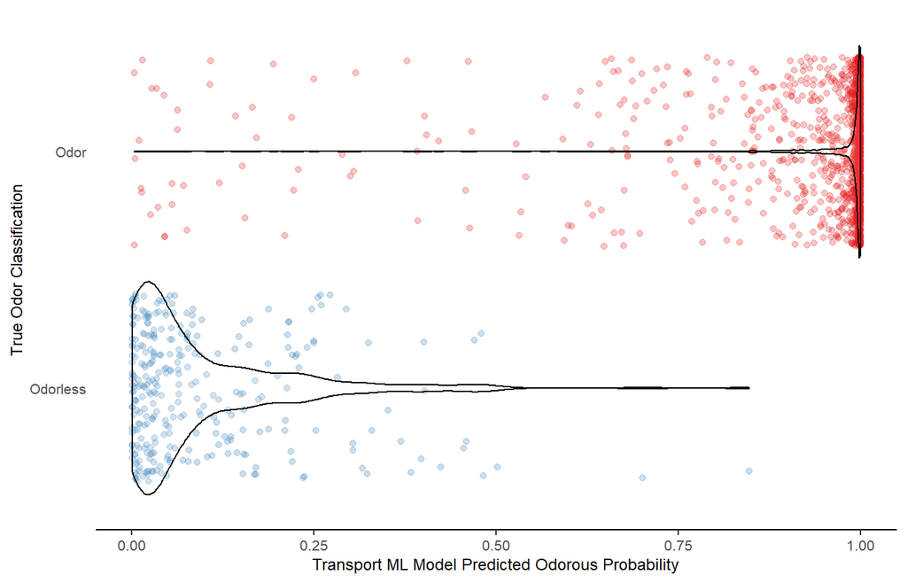

```r
#######################################-
# Figure 1B: Transport ML Model predictions on full dataset
#######################################-

#generate predictions for transport model on full dataset
prob.transport <- predict(xgbL.transport, newdata = ALL_scaled, type = "prob")[,2]

#combine predictions with true odor class
predictions <- ALL_scaled %>%
  select(odor.class) %>%
  mutate(p.transport = prob.transport)

#Make dotplot + violin of model predictions
set.seed(123)
ggplot(predictions, aes(odor.class, p.transport, color = odor.class)) +
  geom_jitter(alpha=0.25) +
  geom_violin(color = "black", alpha = 0.1, scale = "width")+
  coord_flip()+
  theme_classic()+
  labs(x = "True Odor Classification",
       y = "Transport ML Model Predicted Odorous Probability")+
  scale_color_brewer(type = "qual", palette = 6, direction = -1)+
  theme(axis.text.x = element_text(size = 8),
        axis.text.y = element_text(size = 8),
        axis.title.x = element_text(size = 9),
        axis.title.y = element_text(size = 9),
        axis.line.y = element_blank(),
        axis.ticks.y = element_blank(),
        legend.position="none")
```

```r
#ggsave("figures/final/Fig1B.png", width = 3.6, height = 2)
#ggsave("figures/final/Fig1B.pdf", width = 3.6, height = 2)
```

## 4.2 Figure 1C

Odorous and odorless molecules in transport space. LogP and log(vapor pressure (mmHg)) are plotted for each molecule in the dataset; odorous molecules are represented by circles and odorless by x’s, and molecules are colored by Transport-feature ML model-generated odorous probabilities. A logistic regression-generated 50% odorous probability boundary for solids or liquids (Equation 1) is plotted as a solid line and the boundary for gases (Equation 2) is plotted as a dashed line; increasing the value of any feature by X increases the log odds of odorousness by k*X, where k is the corresponding model coefficient.

```r
#######################################-
# Figure 1C: Transport ML Model predictions visualizations
#######################################-

#read in original transport model
xgbL.transport <- readRDS("xgbL.transport.rds")



#generate predictions for transport model on full dataset
prob.transport <- predict(xgbL.transport, newdata = ALL_scaled, type = "prob")[,2]

#combine predictions with true odor class
predictions <- ALL_scaled %>%
  select(odor.class, SMILES) %>%
  mutate(p.transport = prob.transport) %>%
  left_join(S1 %>% select(SMILES, boiling.point.best.available, vapor.pressure.best.available, MLOGP))%>%
  mutate(BP_Kelvin = boiling.point.best.available + 273.15)


#Visualize model predictions in transport space
predictions <- predictions %>%
  mutate(vapor.pressure.best.available = case_when(vapor.pressure.best.available == 0 ~ 1E-15,
                                                   TRUE ~ vapor.pressure.best.available)) %>%
  mutate(logVP = log10(vapor.pressure.best.available))

#equations from Rick, y = (-a*x - c)/b
gas.eq <- function(x) {(1.21*x - 6.13)/-0.75}
liquid.eq <- function(x) {(-0.69*x - 3.64)/0.40}

#get constants for equations
#Eqn 1
#gas log(VP) coefficient
1.21/-0.75 # -1.61
#gas constant
-6.13/-0.75 # 8.17

#Eqn 2
#liquid log(VP) coefficient
-0.69/0.40 # -1.725
#liquid constant
-3.64/0.4 # -9.10
```

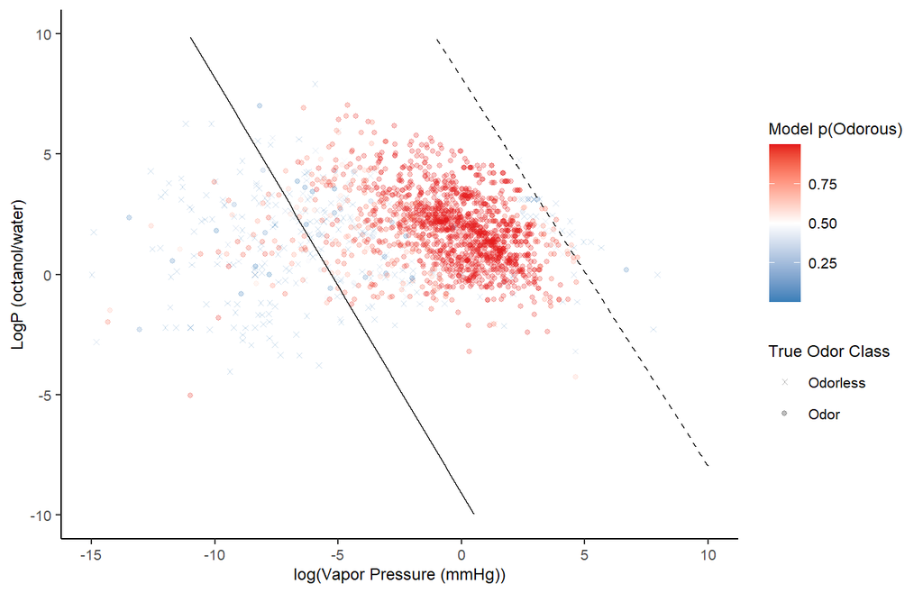

```r
#plot molecules in transport space with linear odorous/odorless bounds
ggplot(predictions, aes(logVP, MLOGP, color = p.transport, shape = odor.class)) +
  geom_point(alpha=0.25, size = 1) +
  stat_function(fun = gas.eq, color = "black", linetype = 2)+
  stat_function(fun = liquid.eq, color = "black", linetype = 1)+
  scale_color_gradient2(low = "#377eb8", mid = "white", high = "#e41a1c", midpoint = 0.5) +
  scale_shape_manual(values = c(4,19))+
  theme_classic()+
  labs(x = "log(Vapor Pressure (mmHg))",
       y = "LogP (octanol/water)",
       color = "Model p(Odorous)",
       shape = "True Odor Class")+
  xlim(-15, 10)+
  ylim(-10, 10)+
  theme(axis.text.x = element_text(size = 8),
        axis.text.y = element_text(size = 8),
        axis.title.x = element_text(size = 9),
        axis.title.y = element_text(size = 9),
        legend.title = element_text(size = 9),
        legend.text = element_text(size = 8))
```

```r
#ggsave("figures/final/Fig1C.png", width = 4.5, height = 2.8)
#ggsave("figures/final/Fig1C.pdf", width = 4.5, height = 2.8)
```

### 4.2.1 Figure 1D

Density of odorous and odorless molecules in transport space defined by molecular weight and number of heteroatoms. Each successive contour line indicates a step increase in density (odorous, red = 0.05%; odorless, blue = 0.01%). Each molecule has an integer number of heteroatoms, but these values are jittered along the y-axis to better show density. Plotted within the black box, molecules that obey the “rule of three” are generally odorous.

```r
#######################################-
#Figure 1D: Rule of Three figure ------
#######################################-

#print ratio of odorous:odorless molecules in dataset
table(S1$odor.class) #1615 odor, 309 odorless

#finding the best easy filter
S1 %>%
  filter(MW > 30 & MW < 300) %>%
  filter(nHet <3)%>%
  select(odor.class) %>%
  table()

#RULE OF 3: 30 < MW < 300 & nHet <3
#1094 odor, 49 odorless
1094/(1094+49) #95.7% odors
1094/1615 #captures 67.7% of odors = sensitivity
(309-49)/309 #excludes 84.1% odorless molecules = specificity
(1094/(1615-1094))/(49/(309-49)) #odds ratio = odds pass filter is odor/odds pass filter if not = 11.1
```

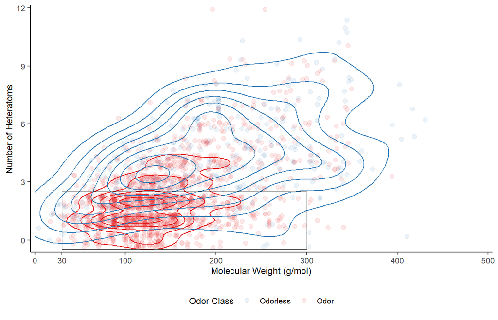

```r
#density map
set.seed(123)
ggplot(S1) +
  geom_jitter( aes(x=MW, y=nHet, color=odor.class), alpha = 0.1, size=2)+
  scale_colour_brewer(type="qual", palette = 6, direction = -1) +
  geom_density_2d(data = S1[S1$odor.class == "Odor",], aes(x=MW, y=nHet), color = "#e41a1c") +
  geom_density_2d(data = S1[S1$odor.class == "Odorless",], aes(x=MW, y=nHet), color = "#377eb8") +
  xlab("Molecular Weight (g/mol)") + ylab("Number of Heteratoms") +
  scale_x_continuous(limits = c(0,500),expand = c(0.01, 0.01), breaks = c(0, 30, 100, 200, 300, 400, 500))+
  scale_y_continuous(limits = c(-0.5,12),expand = c(0.01, 0.01))+
  geom_segment(aes(x=30, y=2.5, xend=300, yend=2.5), color = "black", size=0.3)+
  geom_segment(aes(x=30, y=-0.5, xend=30, yend=2.5), color = "black", size=0.3)+
  geom_segment(aes(x=300, y=-0.5, xend=300, yend=2.5), color = "black", size=0.3)+
  geom_segment(aes(x=30, y=-0.5, xend=300, yend=-0.5), color = "black", size=0.3)+
  #geom_text( aes(x = 180, y = -0.1, label = "96% odorous"), color = "black", size = 3)+
  labs(color = "Odor Class")  +
  theme_classic() +
  theme(axis.text.x = element_text(size = 8),
        axis.text.y = element_text(size = 8),
        axis.title.x = element_text(size = 9),
        axis.title.y = element_text(size = 9),
        legend.text = element_text(size=8),
        legend.title = element_text(size=9),
        #legend.position = c(0.2, 0.9))
        legend.position = "bottom")
```

```r
#ggsave("figures/final/Fig1D.png", height = 3, width = 3)
#ggsave("figures/final/Fig1D.pdf", height = 3, width = 3)
```

```r
#extract contour densities for Odorless compounds
gg <- ggplot(S1) +
  geom_density_2d(data = S1[S1$odor.class == "Odorless",], aes(x=MW, y=nHet) )
gb <- ggplot_build(gg)
gbd <- gb$data[[1]]
unique(gbd$level) #1e-04 2e-04 3e-04 4e-04 5e-04 6e-04 7e-04


#extract contour densities for Odorous compounds
gg2 <- ggplot(S1) +
    geom_density_2d(data = S1[S1$odor.class == "Odor",], aes(x=MW, y=nHet))
gb <- ggplot_build(gg2)
gbd <- gb$data[[1]]
unique(gbd$level) # = 0.0005 0.0010 0.0015 0.0020 0.0025
```

## 4.3 Figure 1E

Figure 1E is produced in the file extrapolating_odor_model_gdb.ipynb under the header “Domains of Validity for odor/odorless models”.

Heatmap of mean AUROC generated by the transport ML, many-feature ML, and the “rule of three” models for molecules of common chemical classes (number of matching molecules in parentheses).

## 4.4 Figure 2

Common inaccuracies in data impact model performance.

### 4.4.1 Figure 2A

Difference between experimentally determined boiling point (BP) values and BP values calculated using the Burnop (8) and Banks (9) methods.

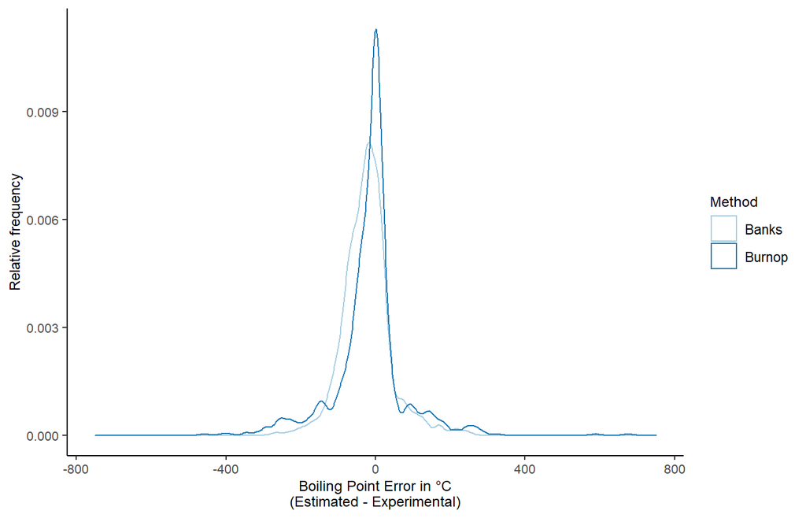

```r
#######################################-
#Figure 2A: Compare BP error of Banks and Burnop eqns-----
#######################################-

#plot error in Burnop and Banks estimates of boiling point compared with experimental values
S1 %>%
  filter(nC + nO + nN + nF + nCL + nBR + nI == nSK) %>% #filter to molecules w/i domain of Burnop applicability
  filter(!is.na(boiling.point.experimental))%>%
  mutate(Banks = (boiling.point.estimate.Banks - boiling.point.experimental))%>%
  mutate(Burnop = (boiling.point.estimate.Burnop - boiling.point.experimental))%>%
  pivot_longer(Banks:Burnop, names_to = "Method", values_to = "BPerror")%>%
  ggplot( aes(BPerror, color = Method))+
  geom_density()+
  xlim(-750,750)+
  xlab("Boiling Point Error in °C\n(Estimated - Experimental)")+
  ylab("Relative frequency")+
  theme_classic()+
  scale_color_brewer(type="qual", palette = 3)+
  theme(axis.text.x = element_text(size = 8),
        axis.text.y = element_text(size = 8),
        axis.title.x = element_text(size = 9),
        axis.title.y = element_text(size = 9),
        legend.title = element_text(size=9))
```

```r
#ggsave("figures/final/Fig2A.png", width = 3.5, height = 3)
#ggsave("figures/final/Fig2A.pdf", width = 4, height = 2)
```

### 4.4.2 Figure 2B

Odor classification predictions by transport-feature ML models using only estimated BP values calculated by the Burnop method.

```r
## Generate training data for BP estimate models - this must be done separately because of NA values in Banks and Burnop estimate columns, full pre-processing protocol does not accept NA's

 #select only columns needed for model training
train_BPest <- S1 %>% filter(dataset.assigned != "test") %>% select(odor.class, boiling.point.estimate.Banks, boiling.point.estimate.Burnop, MLOGP)

#generate pre-processing procedure to scale (0 to 1)
set.seed(111)
preProc_BPest <- preProcess(train_BPest[,-1], method = c("range"), na.remove = TRUE, verbose = FALSE, rangeBounds = c(0, 1))

#apply pre-processing to datasets
train_scaled_BPest <- predict(preProc_BPest, train_BPest)
ALL_scaled_BPest <- predict(preProc_BPest, S1)

#apply SMOTE procedure to rebalance odor:odorless examples
set.seed(123)
#uses scaled data (for everything model)
train_smote_BPest <- SMOTE(odor.class ~., train_scaled_BPest, perc.over = (100 + 50*6), k=5, perc.under = 200)
```

```r
#######################################-
#Figure 2B: Burnop BP Estimate model accuracy-----
#######################################-

if (file.exists("xgbL.Burnop.rds")){
  xgbL.Burnop <- readRDS("xgbL.Burnop.rds")
 }else {

#filter training set
train_Burnop <- train_smote_BPest %>% select(odor.class, boiling.point.estimate.Burnop, MLOGP) %>%
  filter(! is.na(boiling.point.estimate.Burnop))

#train model
set.seed(train.seeds[6])
      xgbL.Burnop <- train(odor.class~., data=train_Burnop,
                         method = "xgbLinear",
                         trControl = fit.control,
                         metric = "ROC",
                         tuneGrid = xgbTuningGrid,
                         na.action = na.roughfix)
#save model
saveRDS(xgbL.Burnop, "xgbL.Burnop.rds")
}
```

```r
#view max cross-validation AUROC
max(xgbL.Burnop$results$ROC) #CV AUROC 0.93

#Burnop BP estimate model predictions
Burnop.prob <- predict(xgbL.Burnop, newdata = ALL_scaled_BPest, type = "prob")[,2]

#combine predictions with true odor class
Burnop_predictions <- ALL_scaled_BPest %>%
  filter(! is.na(boiling.point.estimate.Burnop)) %>%
  select(odor.class) %>%
  mutate(p.transport = Burnop.prob)
```

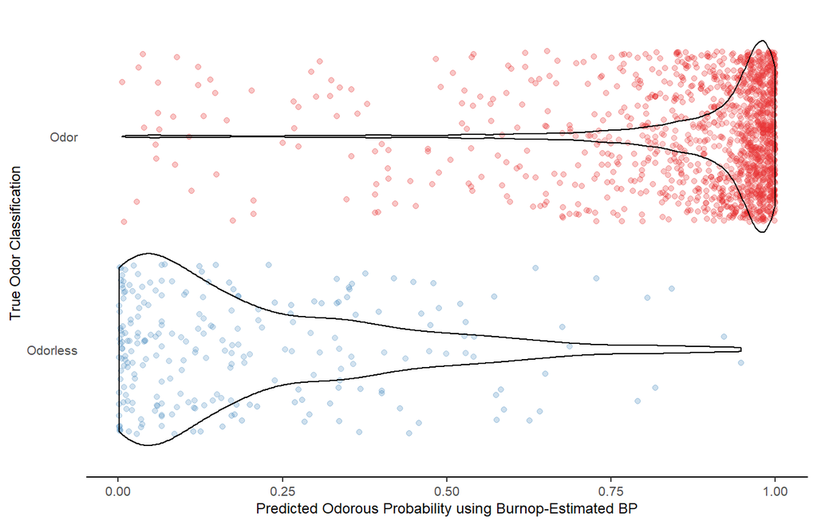

```r
#Make dotplot + violin of model predictions - Burnop edition
set.seed(123)
ggplot(Burnop_predictions, aes(odor.class, p.transport, color = odor.class)) +
  geom_jitter(alpha=0.25) +
  geom_violin(color = "black", alpha = 0.1, scale = "width")+
  coord_flip()+
  theme_classic()+
  labs(x = "True Odor Classification",
       y = "Predicted Odorous Probability using Burnop-Estimated BP")+
  scale_color_brewer(type = "qual", palette = 6, direction = -1)+
  theme(axis.text.x = element_text(size = 8),
        axis.text.y = element_text(size = 8),
        axis.title.x = element_text(size = 9),
        axis.title.y = element_text(size = 9),
        axis.line.y = element_blank(),
        axis.ticks.y = element_blank(),
        legend.position="none")
```

```r
#ggsave("figures/final/Fig2B.png", width = 4, height = 2)
#ggsave("figures/final/Fig2B.pdf", width = 4, height = 1.8)
```

### 4.4.3 Figure 2C

Odor classification predictions by transport-feature ML models using only estimated BP values calculated by the Banks method.

```r
#######################################-
#Figure 2C: Banks BP Estimate model accuracy-----
#######################################-

if (file.exists("xgbL.Banks.rds")){
  xgbL.Banks <- readRDS("xgbL.Banks.rds")
}else {
#filter training set
train_Banks <- train_smote_BPest %>% select(odor.class, boiling.point.estimate.Banks, MLOGP) %>%
  filter(! is.na(boiling.point.estimate.Banks))


S1 %>% filter(is.na(boiling.point.estimate.Banks)) %>% nrow()

#train model
set.seed(train.seeds[6])
      xgbL.Banks <- train(odor.class~., data=train_Banks,
                         method = "xgbLinear",
                         trControl = fit.control,
                         metric = "ROC",
                         tuneGrid = xgbTuningGrid,
                         na.action = na.roughfix)
#save model
saveRDS(xgbL.Banks, "xgbL.Banks.rds")
}
```

```r
#view max cross-validation AUROC
max(xgbL.Banks$results$ROC)  #CV AUROC 0.95

#Banks BP estimate model predictions
Banks.prob <- predict(xgbL.Banks, newdata = ALL_scaled_BPest, type = "prob")[,2]

#combine predictions with true odor class
Banks_predictions <- ALL_scaled_BPest %>%
  filter(! is.na(boiling.point.estimate.Banks)) %>%
  select(odor.class) %>%
  mutate(p.transport = Banks.prob)
```

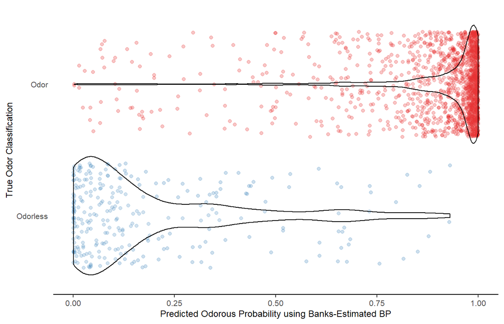

```r
#Make dotplot + violin of model predictions
set.seed(123)
ggplot(Banks_predictions, aes(odor.class, p.transport, color = odor.class)) +
  geom_jitter(alpha=0.25) +
  geom_violin(color = "black", alpha = 0.1, scale = "width")+
  coord_flip()+
  theme_classic()+
  labs(x = "True Odor Classification",
       y = "Predicted Odorous Probability using Banks-Estimated BP")+
  scale_color_brewer(type = "qual", palette = 6, direction = -1)+
  theme(axis.text.x = element_text(size = 8),
        axis.text.y = element_text(size = 8),
        axis.title.x = element_text(size = 9),
        axis.title.y = element_text(size = 9),
        axis.line.y = element_blank(),
        axis.ticks.y = element_blank(),
        legend.position="none")
```

```r
#ggsave("figures/final/Fig2C.png", width =4, height = 2)
#ggsave("figures/final/Fig2C.pdf", width =4, height = 1.8)
```

### 4.4.4 Figure 2D

Human subject-classified molecules in transport space defined by BP and log P. Many clearly non-volatile molecules were initially classified as odors due to odorous contaminants.

```r
#######################################-
#Figure 2D: Reclassified molecules in transport feature space-----
#######################################-

#what percent of lab-tested molecules initially classified as Odorous were reclassified through QC process?
nrow(S2[S2$initial.odor.class == "Odor",]) #111 Odors initially
nrow(S2[S2$QC.reclassified == "yes",]) #24 reclassified
nrow(S2[S2$QC.reclassified == "yes",])*100/nrow(S2[S2$initial.odor.class == "Odor",]) #21.6% reclassified

#create small df with lab-tested molecules, reclassification info - PLOT 3 CATEGORIES
reclass <- S1 %>%
  filter(odor.class.source == "Lab-Tested") %>%
  left_join(S2, by = "SMILES") %>%
  select(compound.name, odor.class, QC.reclassified, boiling.point.best.available, MLOGP, nHet) %>%
  mutate(odor.class = as.character(odor.class))%>%
  mutate(odor.3class = ifelse(QC.reclassified == "yes", "Odorless with odorous contaminants", odor.class)) %>%
  mutate(BP.K = boiling.point.best.available + 273.15)
```

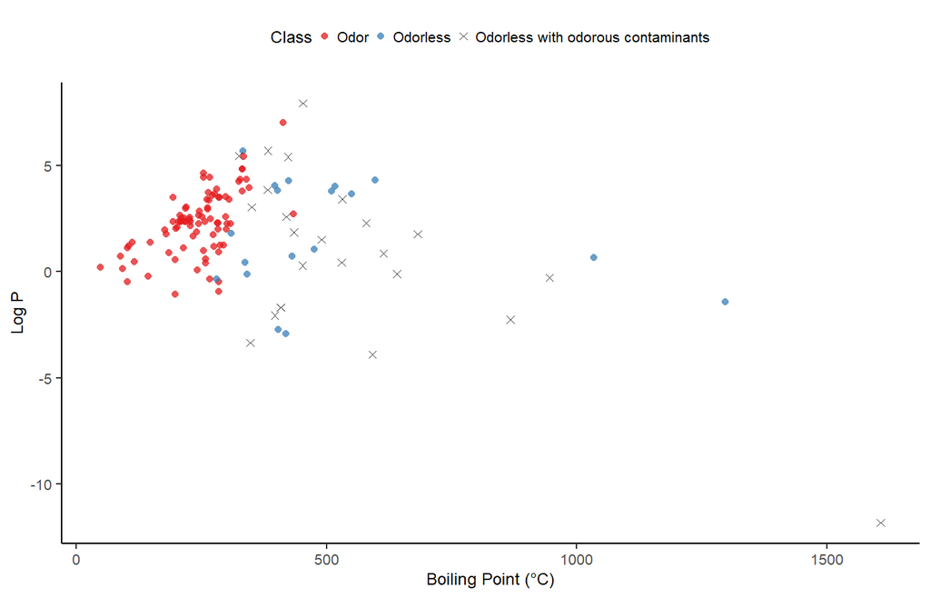

```r
#plot molecules, showing reclassified molecules, in transport space
set.seed(123)
ggplot(reclass, aes(x=boiling.point.best.available, y=MLOGP, color=odor.3class, shape=odor.3class)) +
  geom_jitter(alpha = 0.75) +
  theme_classic() +
  scale_color_manual(values = c("#e41a1c", "#377eb8", "black"))+
  scale_shape_manual(values = c(16, 16, 4))+
  #scale_x_log10()+
  theme(legend.position = "top",
        axis.text.x = element_text(size = 8),
        axis.text.y = element_text(size = 8),
        axis.title.x = element_text(size = 9),
        axis.title.y = element_text(size = 9),
        legend.text = element_text(size = 8),
        legend.title = element_text(size = 9),
        legend.key.width = unit(0.05, "in")) +
  xlab("Boiling Point (°C)") +
  #ylab("Number of Heteratoms") +
  ylab("Log P") +
  labs(color = "Class", shape = "Class")
```

```r
#ggsave("figures/final/Fig2D.png", height = 3, width = 4)
#ggsave("figures/final/Fig2D.pdf", height = 3, width = 4)
```

### 4.4.5 Figure 2E

Transport-feature ML model odor predictions for human subject-classified molecules. Chemical compounds that are odorless but had odorous contaminants are correctly predicted to be odorless by the model.

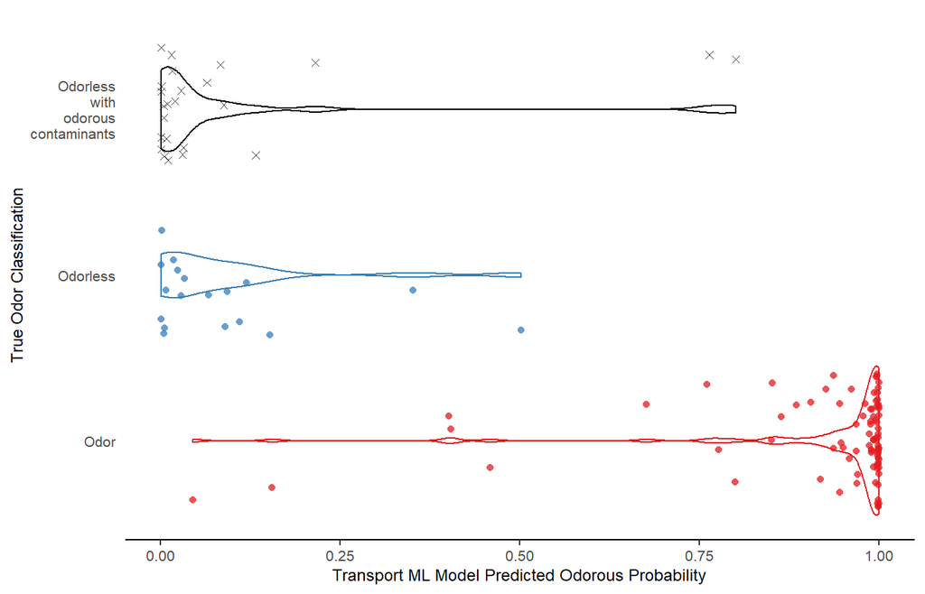

```r
#######################################-
#Figure 2E: Validation set predictions - models catch misclassifications-----
#######################################-

#generate predictions for transport ML model on full dataset
prob.transport <- predict(xgbL.transport, newdata = ALL_scaled, type = "prob")[,2]

#combine predictions with descriptive data
LabTest_predictions <- ALL_scaled %>%
  mutate(p.transport = prob.transport) %>%
  right_join(S2, by = "SMILES") %>%
  select(1:3, QC.reclassified, p.transport) %>%
  mutate(odor.class = as.character(odor.class))%>%
  mutate(odor.3class = ifelse(QC.reclassified == "yes", "Odorless with odorous contaminants", odor.class))

#Make dotplot of model predictions, showing reclassified molecules
set.seed(123)
ggplot(LabTest_predictions, aes(odor.3class, p.transport, color = odor.3class, shape = odor.3class)) +
  geom_violin()+
  geom_jitter(alpha=0.75) +
  coord_flip()+
  theme_classic()+
  labs(x = "True Odor Classification",
       y = "Transport ML Model Predicted Odorous Probability")+
  scale_x_discrete(labels = function(x) str_wrap(x, width = 10))+
  scale_color_manual(values = c("#e41a1c", "#377eb8", "black"))+
  scale_shape_manual(values = c(16, 16, 4))+
  theme(axis.text.x = element_text(size = 8),
        axis.text.y = element_text(size = 8),
        axis.title.x = element_text(size = 9),
        axis.title.y = element_text(size = 9),
        axis.line.y = element_blank(),
        axis.ticks.y = element_blank(),
        legend.position="none")
```

```r
#ggsave("figures/final/Fig2E.png", width = 4, height = 2.6)
#ggsave("figures/final/Fig2E.pdf", width = 4, height = 2.6)
```

```r
#######################################-
#Figure 2 Associated Stats ------
#######################################-

#compare transport ML CV AUROC
max(xgbL.transport$results$ROC) # CV AUROC 0.99

#summary stats of boiling point error
S1 %>%
  filter(!is.na(boiling.point.experimental))%>%
  mutate(Banks = abs(boiling.point.experimental - boiling.point.estimate.Banks))%>%
  mutate(Burnop = abs(boiling.point.experimental - boiling.point.estimate.Burnop))%>%
  pivot_longer(Banks:Burnop, names_to = "Method", values_to = "BPerror")%>%
  group_by(Method)%>%
  summarize(med = median(BPerror, na.rm = T),
            max = max(BPerror, na.rm = T),
            min = min(BPerror, na.rm = T))

#error rates  of models trained/tested on estimated bp
#banks boiling point error rate
Banks_predictions %>%
  filter(odor.class == "Odor" & p.transport < 0.5 |
           odor.class == "Odorless" & p.transport > 0.5) %>%
  nrow() #114 errors
114/nrow(Banks_predictions) # 6.0% error rate

#burnop boiling point error rate
Burnop_predictions %>%
  filter(odor.class == "Odor" & p.transport < 0.5 |
           odor.class == "Odorless" & p.transport > 0.5) %>%
   nrow() #86 errors
86/nrow(predictions) # 4.5% error rate

#compare to error rate using best available boiling point value
predictions %>%
  filter(odor.class == "Odor" & p.transport < 0.5 |
           odor.class == "Odorless" & p.transport > 0.5) %>%
  nrow() #48 errors
50/nrow(predictions) # 2.6% error rate

### AUROC on original classifications (pre-GC QC)

#add original odor class to test set
test_scaled_initialClass <- test_scaled %>%
  left_join(S2, by = "SMILES") %>%
  select(initial.odor.class, boiling.point.best.available, vapor.pressure.best.available, MLOGP)

#generate ML transport predictions on test set molecules
test.prob.i <- predict(xgbL.transport, newdata = test_scaled_initialClass, type = "prob")[,1]
#compare transport ML odor class probabilities to true class
test.pred.i <- prediction(test.prob.i, test_scaled_initialClass$initial.odor.class)
#calculate auroc
test.perf.i <- performance(test.pred.i, "auc")
#print auroc
test.perf.i@y.values[[1]] #AUROC = 0.81
```

## 4.5 Figure 3

The transport model can be used to predict the population of odor space.

### 4.5.1 Figure 3A

Proportion of molecules predicted by the transport ML model to be odorous as a function of heavy atom count (HAC). Red circles show the mean probability generated for HAC tranches from the GDB database (13) with standard error indicated.

```r
### Apply transport model to generate predictions for GDB molecules
GDB.Banks <- readRDS("GDB.Banks.rds") #very similar to xgbL.Banks - some changes to pre-processing occurred such that new xgbL.Banks gives slightly different results
#apply model to generate probabilities - using Banks estimate because no experimental values are available
S3$odor.probability <- predict(GDB.Banks, newdata = S3, type = "prob")[,2]
```

```
## [13:32:48] WARNING: amalgamation/../src/learner.cc:854: Loading model from XGBoost < 1.0.0, consider saving it again for improved compatibility
```

```r
#number of possible molecules in GDB-17 per HAC
GDB.count <- c(3,6,14,47,219,1091,6029,37435,243233,1670163,12219460,72051665,836687200,
                  2921398415,15084103347,38033661355,109481780580)

#how many odorous molecules? sum odorous probabilities
GDBprob.byHAC <- S3 %>%
  group_by(HAC)%>%
  #summarize(meanProb = mean(transport.ML.odor.probability)) %>%
  summarize(meanProb = mean(odor.probability)) %>%
  mutate(possible.molecules = GDB.count) %>%
  mutate(Odors = meanProb*possible.molecules)
```

```r
#generate random binarizations from predicted odorous probabilities
set.seed(111)
for(i in 1:nrow(S3)){
  S3$Trial1[i] <- rbinom(1,1,S3$odor.probability[i])
  S3$Trial2[i] <- rbinom(1,1,S3$odor.probability[i])
  S3$Trial3[i] <- rbinom(1,1,S3$odor.probability[i])
  S3$Trial4[i] <- rbinom(1,1,S3$odor.probability[i])
  S3$Trial5[i] <- rbinom(1,1,S3$odor.probability[i])
  S3$Trial6[i] <- rbinom(1,1,S3$odor.probability[i])
  S3$Trial7[i] <- rbinom(1,1,S3$odor.probability[i])
  S3$Trial8[i] <- rbinom(1,1,S3$odor.probability[i])
  S3$Trial9[i] <- rbinom(1,1,S3$odor.probability[i])
  S3$Trial10[i] <- rbinom(1,1,S3$odor.probability[i])
}
#how variable are the trials?
S3 %>%
  select(Trial1:Trial10)%>%
  colSums() #not very variable

#use data from all 10 simulations
S3.long <- S3 %>%
  pivot_longer(Trial1:Trial10, names_to = "TrialNo", values_to = "Class")

#apply glm-binomial to binomial data for 10 simulations
t1 <- glm(Class ~ HAC, data = S3.long, family = "binomial")
summary(t1)
eq.p <- function (x) {exp(-0.3359223*x + 4.1014314)/(1 + exp(-0.3359223*x + 4.1014314))} #need to manually update from summary(t1)!

#calculate variance
S3 <- S3 %>%
  mutate(Variance = odor.probability*(1-odor.probability))
sum(S3$Variance) #12825.17
```

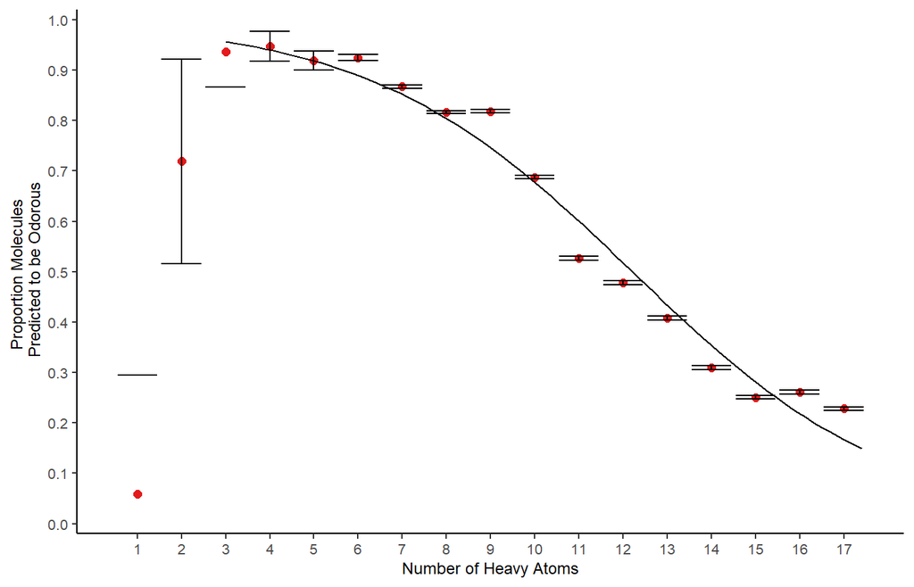

```r
#######################################-
#Figure 3A: Enumerating odor space-Percent Odorous -----
#######################################-

### Make odor probability by HAC plot
plot1 <- S3 %>%
  group_by(HAC) %>%
  mutate(count = n()) %>%
  summarize(Prob.Odor = mean(odor.probability),
            SE = sqrt(sum(Variance))/mean(count))  %>%
  #summarize(Prob.Odor = mean(Class)) %>%
  ggplot( aes(HAC, Prob.Odor)) +
  geom_point(color="#e41a1c", size=2) +
  geom_errorbar( aes(ymin = Prob.Odor - SE, ymax = Prob.Odor+ SE))+
  #geom_violin(aes(group=heavy.atoms)) +
  #geom_bar(stat = "identity", position = "stack")  +
  stat_function(fun=eq.p, xlim = c(3,21)) +
  #geom_smooth()+
  scale_x_continuous(limits = c(0.5,17.5), expand = c(0.05, 0.01), breaks = seq(1,17,1)) +
  scale_y_continuous(limits = c(0,1.0), expand = c(0.02, 0), breaks = seq(0,1.00,0.10)) +
  #theme_minimal() +
  theme_classic()+
  xlab("Number of Heavy Atoms") +
  ylab("Proportion Molecules \n Predicted to be Odorous") +
  labs(fill = "Prediction") +
  theme(plot.title = element_text(hjust = 0.5),
        axis.text.x = element_text(size = 8),
        axis.text.y = element_text(size = 8),
        axis.title.x = element_text(size = 9),
        axis.title.y = element_text(size = 9),
        panel.grid.minor.x = element_blank(),
        panel.grid.minor.y = element_blank())
plot1
```

### 4.5.2 Figure 3B

Estimated number of possible molecules and predicted odorous molecules from the GDB databases as a function of HAC.

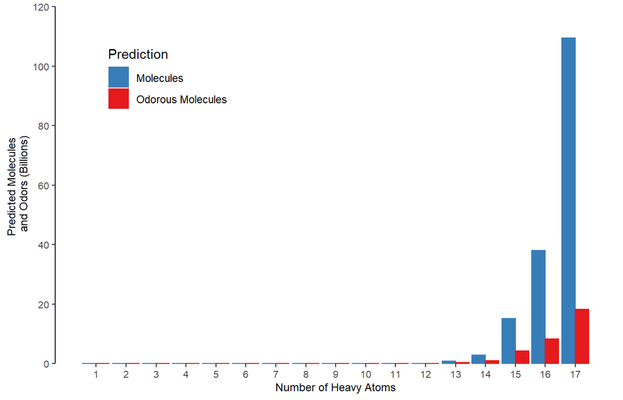

```r
#######################################-
#Figure 3B: Enumerating odor space-Number predicted molecules & odors -----
#######################################-

#make summary table with predicted # odorous molecules by HAC, use HAC-17 molecule count for HAC 18-21
GDBTotal.Estimate <- tibble(HAC = 1:17,
                               Source = c(rep("GDB", 17)),
                               Molecules = c(3,6,14,47,219,1091,6029,37435,243233,1670163,12219460,72051665,836687200,
                                             2921398415,15084103347,38033661355, 109481780580),
                               Prob.Odor = eq.p(1:17),
                               Predicted.Odor = Molecules*Prob.Odor)

#format df to generate plot
p <- GDBTotal.Estimate %>% gather(key = "type", value = "number", -c(1:2,4)) %>%
  mutate(number = number/1E9)%>%
  mutate(type = factor(type, levels = c("Molecules", "Predicted.Odor")))
p$type <- gsub("Predicted.Odor", "Odorous Molecules", p$type)

#plot bar graph of # molecules and predicted # odorous molecules as a function of HAC
plot2 <- ggplot() +
  geom_bar(data=subset(p, HAC<18), aes(HAC, number, fill=type, color=type), stat = "identity", position = "dodge")  +
  scale_x_continuous(limits = c(0.5,17.5), expand = c(0.05, 0.01), breaks = seq(1,17,1)) +
  theme_classic() +
  scale_fill_brewer(name = "Prediction",
                    labels = c("Molecules", "Odorous Molecules"),
                    type="qual", palette = 6, direction = -1) +
  scale_color_brewer(name = "Prediction",
                     labels = c("Molecules", "Odorous Molecules"),
                     type="qual", palette = 6, direction = -1) +
  xlab("Number of Heavy Atoms") +
  ylab("Predicted Molecules \n and Odors (Billions)") +
  #labs(fill = "Prediction") +
  scale_y_continuous(limits = c(0,120),
                     breaks = c(0, 20, 40, 60, 80, 100, 120),
                     expand = c(0, 0)) +
  theme(plot.title = element_text(hjust = 0.5),
        axis.text.x = element_text(size = 8),
        axis.text.y = element_text(size = 8),
        axis.title.x = element_text(size = 9),
        axis.title.y = element_text(size = 9),
        legend.position = c(0.2, 0.8),
        axis.line.x = element_blank())
plot2
```

### 4.5.3 Figure 3C

Cumulative estimates of possible molecules and odorous molecules with increasing HAC on a logarithmic scale. The red datapoint at HAC 17 reflects our conservative estimate of 40 billion odorous molecules.

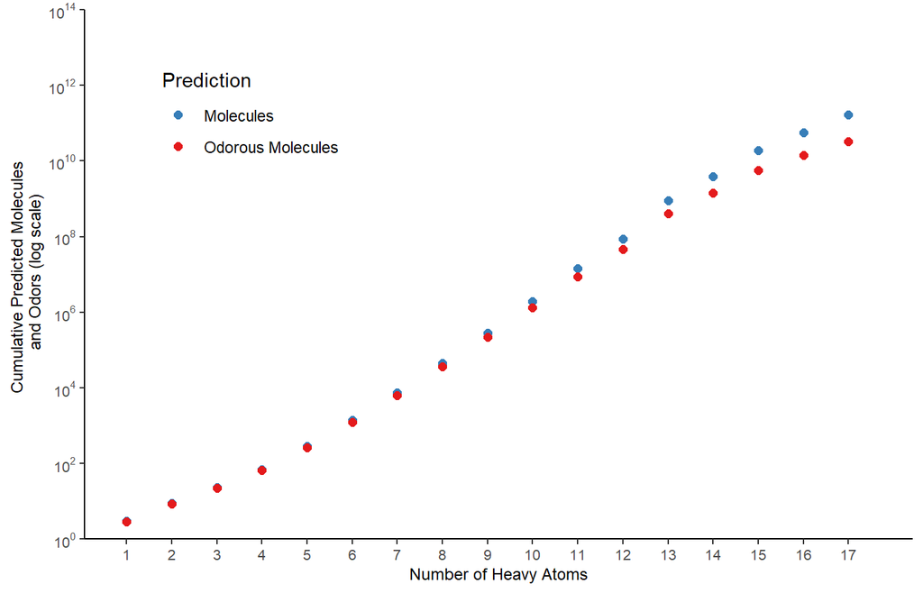

```r
#######################################-
#Figure 3C: Enumerating odor space-Cumumulative predicted molecules & odors -----
#######################################-

#add count of predicted odorous molecules with training set neighbors (tanimoto similarity > 0.4)
# GDBTotal.Extrapolate$Predicted.Odor.with.Neighbor <- c(NA, 4.000000e+00, 1.800000e+01, 5.734884e+01, 1.912597e+02, 6.230417e+02,     1.681699e+03, 5.143657e+03, 1.599945e+04, 4.456209e+04, 1.435397e+05, 3.524895e+05, 1.356514e+06, 4.570052e+06, 1.060369e+07, 1.060369e+07,  1.060369e+07, NA, NA, NA, NA)

#calculate cumulative molecules and predicted odorous molecules as a function of HAC
p2 <- GDBTotal.Estimate %>%
  mutate(Cumulative.Molecules = cumsum(Molecules),
         Cumulative.Odors = cumsum(Predicted.Odor),
         Predicted.Odor.with.Neighbor = c(0, 4.000000e+00, 1.800000e+01, 5.734884e+01, 1.912597e+02, 6.230417e+02,     1.681699e+03, 5.143657e+03, 1.599945e+04, 4.456209e+04, 1.435397e+05, 3.524895e+05, 1.356514e+06, 4.570052e+06, 1.060369e+07, 1.060369e+07,  1.060369e+07)) %>%
  gather(key = "type", value = "number", 6:8)
p2$type <- gsub("Cumulative.Molecules", "Molecules", p2$type)
p2$type <- gsub("Cumulative.Odors", "Odorous Molecules", p2$type)
p2$type <- gsub("Predicted.Odor.with.Neighbor", "Odorous Molecules with \nTrain Set Neighbors", p2$type)

p2 <- p2 %>%
  mutate(type = factor(type, levels = c("Molecules", "Odorous Molecules", "Odorous Molecules with \nTrain Set Neighbors")))

# #plot cumulative molecules and odorous molecules by HAC on a log scale
# plot3 <- ggplot()+
#   geom_point(data=subset(p2, HAC<18), aes(HAC, number, color=type), size=2)  +
#   geom_point(data=subset(p2, HAC>17), aes(HAC, number, color=type), size=2, alpha = 0.3)  +
#   scale_x_continuous(limits = c(1,17.5), expand = c(0.05, 0.1), breaks = seq(1,17,1)) +
#   theme_classic() +
#   scale_color_manual(values = c("#377eb8", "#e41a1c", "#4daf4a")) +
#   xlab("Number of Heavy Atoms") +
#   ylab("Cumulative Predicted Molecules \n and Odors (log scale)") +
#   labs(color = "Prediction") +
#   scale_y_log10(limits=c(1E0, 1E14),
#                 breaks = scales::trans_breaks("log10", function(x) 10^x),
#                 labels = scales::trans_format("log10", scales::math_format(10^.x)),
#                 expand = c(0, 0)) +
#   theme(plot.title = element_text(hjust = 0.5),
#         text = element_text(size=8),
#         legend.position = c(0.25, 0.8))

#plot cumulative molecules and odorous molecules by HAC on a log scale
plot3 <- ggplot()+
  geom_point(data=subset(p2, type %in% c("Molecules", "Odorous Molecules")), aes(HAC, number, color=type), size=2)  +
  scale_x_continuous(limits = c(1,17.5), expand = c(0.05, 0.1), breaks = seq(1,17,1)) +
  theme_classic() +
  scale_color_manual(values = c("#377eb8", "#e41a1c")) +
  xlab("Number of Heavy Atoms") +
  ylab("Cumulative Predicted Molecules \n and Odors (log scale)") +
  labs(color = "Prediction") +
  scale_y_log10(limits=c(1E0, 1E14),
                breaks = scales::trans_breaks("log10", function(x) 10^x),
                labels = scales::trans_format("log10", scales::math_format(10^.x)),
                expand = c(0, 0)) +
  theme(plot.title = element_text(hjust = 0.5),
        axis.text.x = element_text(size = 8),
        axis.text.y = element_text(size = 8),
        axis.title.x = element_text(size = 9),
        axis.title.y = element_text(size = 9),
        legend.position = c(0.2, 0.8))

plot3
```

```r
### print odor space enumeration estimates

#how many odorous molecules? sum odorous probabilities for GDB-17
paste0("A conservative estimate of the number of odorous molecules with 17 or fewer heavy atoms is ", round(sum(GDBprob.byHAC$Odors),0))
```

```
## [1] "A conservative estimate of the number of odorous molecules with 17 or fewer heavy atoms is 39987072324"
```

```r
# #new extrapolated estimate for HAC < 22
# paste0("A conservative estimate of the number of odorous molecules with 21 or fewer heavy atoms is ", round(sum(GDBTotal.Extrapolate$Predicted.Odor),0))
```

```r
#combine figure 3 plots on shared x axis
cowplot::plot_grid(plot1, plot2, plot3, align = "v", ncol = 1, rel_heights = c(0.35, 0.3, 0.35))

#ggsave("figures/final/Fig3ABC.png", height = 6, width = 4)
#ggsave("figures/final/Fig3.pdf", height = 6, width = 4)
```

## 4.6 Figure 4

Visualization of olfactory space highlights understudied regions.

Figure 4 is produced in the file “static.ipynb”.